# Naukri Data Analyst Jobs slides

Importing essential librariesm

```python
import pandas as pd
import numpy as np
import seaborn as sns
import plotly
import cufflinks as cf
from plotly.offline import download_plotlyjs,init_notebook_mode,plot,iplot
init_notebook_mode(connected=True)
cf.go_offline()
import matplotlib.pyplot as plt
%matplotlib inline
```

Reading CSV file

```python
df = pd.read_csv(r"C:\Users\UMAPRIYA\Desktop\Data Analyst_Naukri_Dataset\Final Dataset\Naukri_Data_Analyst_Jobs.csv")
```

```python
df.head()
```

|  | Job Role | Company | Job Type | Location | Experience | Salary per annual | Description | Key Skills | Posted on | Apply link |
| --- | --- | --- | --- | --- | --- | --- | --- | --- | --- | --- |
| 0 | Analyst - Data Services | RF Managed Services | work from office | Chennai | 2-4 Yrs | up to 300000 | GraduatesPost Graduates in any stream Skill Se... | Application support Automation Data conversion... | 30+ Days Ago | https:www.naukri.comjob-listings-Analyst-Data-... |
| 1 | Analyst Programmer- RPA | CreditAccess Grameen | work from office | Chennai | 2-6 Yrs | up to 300000 | Proven ability to bridge technology and Busine... | Python Django power bi retail finance | 7 Days Ago | https:www.naukri.comjob-listings-Analyst-progr... |
| 2 | Analytical Executive | GVK Emergency Management and Research Institut... | work from office | Chennai | 4-7 Yrs | up to 300000 | Experience working in a team setting and desir... | Excel Data Analysis SQL Server Data mining res... | 1 Day Ago | https:www.naukri.comjob-listings-analytical-ex... |
| 3 | Analytics Consultant | Chryselys | work from office | Chennai | 2-5 Yrs | up to 300000 | 5 years of relevant post-collegiate job experi... | IT Skills Data Science Cloud AWS Tableau Azure... | 30+ Days Ago | https:www.naukri.comjob-listings-analytics-con... |
| 4 | Analytics Modeler - SAS Economics - Candidates... | Smartlyhr | work from office | Chennai | 3-6 Yrs | up to 300000 | Demand & Time Series forecasting modeling Sala... | Economic Research SAS | 21 Days Ago | https:www.naukri.comjob-listings-analytics-mod... |

```python
df.tail()
```

|  | Job Role | Company | Job Type | Location | Experience | Salary per annual | Description | Key Skills | Posted on | Apply link |
| --- | --- | --- | --- | --- | --- | --- | --- | --- | --- | --- |
| 404 | Sr. OfficerAssistant Manager Data Analytics | Rsm Gc Advisory Services | work from office | Chennai | 2-4 Yrs | 1000000 - 1500000 | Self-motivated innovative capable of handling ... | Data analysis Assurance Manager Quality Assura... | 30+ Days Ago | https:www.naukri.comjob-listings-sr-officer-as... |
| 405 | Sr. Platform Analyst | Philips | work from office | Chennai | 10-12 Yrs | 1000000 - 1500000 | Looking at the challenges the world is facing ... | PLM ERP Data migration SAP Analytical CAD Scru... | 30+ Days Ago | https:www.naukri.comjob-listings-sr-platform-A... |
| 406 | Sr. Process Data Engineer | Shell Pvt Ltd | work from office | Chennai | 3-6 Yrs | 1000000 - 1500000 | Full time equivalent Degree Petum Engineering ... | Data management Technical writing Project mana... | 7 Days Ago | https:www.naukri.comjob-listings-sr-process-Da... |
| 407 | Sr. Process Data Engineer - PRS | Shell Pvt Ltd | work from office | Chennai | 1-4 Yrs | 1000000 - 1500000 | The successful candidate should have a Univers... | Data analysis Assurance Data management Risk m... | 7 Days Ago | https:www.naukri.comjob-listings-sr-process-Da... |
| 408 | Team Lead- Data Analysis | Spectrum Talent Management Pvt. Ltd | work from office | Chennai | 7-12 Yrs | 1000000 - 1500000 | Must be having good exposure into Data managem... | Data analysis Team Handling team lead Data rep... | 30+ Days Ago | https:www.naukri.comjob-listings-team-lead-Dat... |

```python
df.shape
```

```
(409, 10)
```

There are 409 rows and 10 columns in the data set

```python
df.info()
```

```
<class 'pandas.core.frame.DataFrame'>
RangeIndex: 409 entries, 0 to 408
Data columns (total 10 columns):
 #   Column             Non-Null Count  Dtype
---  ------             --------------  -----
 0   Job Role           409 non-null    object
 1   Company            409 non-null    object
 2   Job Type           409 non-null    object
 3   Location           409 non-null    object
 4   Experience         409 non-null    object
 5   Salary per annual  409 non-null    object
 6   Description        409 non-null    object
 7   Key Skills         409 non-null    object
 8   Posted on          409 non-null    object
 9   Apply link         409 non-null    object
dtypes: object(10)
memory usage: 32.1+ KB
```

Overall information about the dataset

```python
df.describe()
```

|  | Job Role | Company | Job Type | Location | Experience | Salary per annual | Description | Key Skills | Posted on | Apply link |
| --- | --- | --- | --- | --- | --- | --- | --- | --- | --- | --- |
| count | 409 | 409 | 409 | 409 | 409 | 409 | 409 | 409 | 409 | 409 |
| unique | 297 | 213 | 4 | 10 | 58 | 4 | 340 | 381 | 30 | 402 |
| top | Data Analyst | Huquo Consulting Pvt. Ltd | work from office | Chennai | 3-8 Yrs | 600000 - 1000000 | Perform other related duties as required and a... | metaData Data management Test scripts Talent a... | 30+ Days Ago | https:www.naukri.comjob-listings-opportunity-w... |
| freq | 23 | 24 | 360 | 372 | 41 | 150 | 5 | 4 | 215 | 2 |

This shows the unique value,total count, top values and top value frequency per column

```python
df.isnull().sum()
```

```
Job Role             0
Company              0
Job Type             0
Location             0
Experience           0
Salary per annual    0
Description          0
Key Skills           0
Posted on            0
Apply link           0
dtype: int64
```

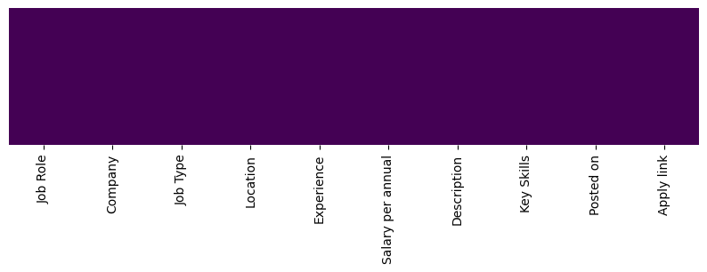

```python
plt.figure(figsize=(10,2))
sns.heatmap(df.isnull(), yticklabels=False, cbar=False, cmap='viridis')
```

Graph for showing the null values in a each column.

There is no missing values in this file

```python
import cufflinks as cf
cf.go_offline()
```

```python
df['Location'].value_counts()[0:7].iplot(kind='bar',colors='brown')
```

[interactive chart not shown]

To summarize above graph in short,the most jobs asre in Chennai

```python
df['Salary per annual'].value_counts()[0:8].iplot(kind='bar',colors='black')
```

[interactive chart not shown]

```python
df['Experience'].value_counts()[0:17].iplot(kind='bar')
```

[interactive chart not shown]

To summarize above graph in short, There are around 41 jobs needs 3 to 8 year of job experience, 31 jobs which needs 5 to 10 years experience, 22 jobs with 3 to 6 years of experience.

```python
df['Job Type'].value_counts()[0:10].iplot(kind='bar',colors='red')
```

[interactive chart not shown]

```python
df['Job Role'].value_counts()[0:10].iplot(kind='bar',colors='green')
```

[interactive chart not shown]

This graph gives an top job role in naukri.com against the Data Analyst in Tamilnadu.

```python
df['Company'].value_counts()[0:20].iplot(kind='bar',colors='gold')
```

[interactive chart not shown]

This graph gives an Top hiring Company in Tamilnadu.

```python
df['Posted on'].value_counts()[0:20].iplot(kind='line',colors='blue')
```

[interactive chart not shown]

Above the graph shows the most of the jobs posted 30+ days ago.

In short, according to given data, Data analyst jobs on Naukri.com are related to Data Science and Analytics industry against Tamilnadu filter and Most of the job recruiters are from Chennai region.